# ------------------------------------------------------------------------------------------

## ------------------------------------------------------------------------------------------------------------

# TASK 7

## Overlapping Line Plots with Annotations: Plot three trigonometric functions (sine, cosine, and tangent) on the same graph over the range of 0 to 2π. Ensure each line has a different style and color. Add annotations for key points where the functions intersect or reach significant values (e.g., sine and cosine crossing at π/4). Include a legend and grid.

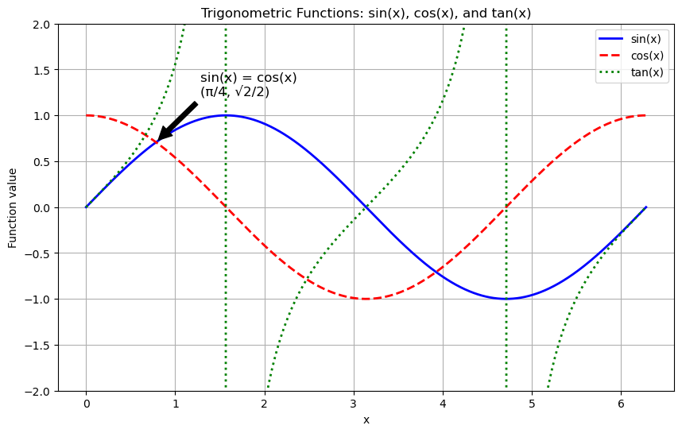

```python
import numpy as np
import matplotlib.pyplot as plt

# Define the range
x = np.linspace(0, 2 * np.pi, 1000)

# Compute function values
sin_x = np.sin(x)
cos_x = np.cos(x)
tan_x = np.tan(x)

# Plot the functions
plt.figure(figsize=(10, 6))

# Plot sine function
plt.plot(x, sin_x, label='sin(x)', color='blue', linestyle='-', linewidth=2)

# Plot cosine function
plt.plot(x, cos_x, label='cos(x)', color='red', linestyle='--', linewidth=2)

# Plot tangent function
plt.plot(x, tan_x, label='tan(x)', color='green', linestyle=':', linewidth=2)

# Add grid
plt.grid(True)

# Annotate intersection of sin(x) and cos(x) at x = π/4
x_intersection = np.pi / 4
y_intersection = np.sin(x_intersection)  # sin(x) = cos(x) at this point
plt.annotate(
    'sin(x) = cos(x)\n(π/4, √2/2)',
    xy=(x_intersection, y_intersection),
    xytext=(x_intersection + 0.5, y_intersection + 0.5),
    arrowprops=dict(facecolor='black', shrink=0.05),
    fontsize=12
)

# Annotate where tan(x) crosses y-axis
plt.annotate(
    'tan(x) at x = π/2 (Asymptote)',
    xy=(np.pi / 2, np.tan(np.pi / 2)),
    xytext=(np.pi / 2 + 0.5, 10),
    arrowprops=dict(facecolor='black', shrink=0.05),
    fontsize=12
)

# Add legend
plt.legend()

# Set labels and title
plt.xlabel('x')
plt.ylabel('Function value')
plt.title('Trigonometric Functions: sin(x), cos(x), and tan(x)')

# Set limits for y-axis to avoid extreme values of tan(x)
plt.ylim(-2, 2)

# Show plot
plt.show()
```

## ------------------------------------------------------------------------------------------------------------

# TASK 8

## **Advanced Subplots with Different Scales:** Create a figure with three subplots: the first subplot shows a linear function, the second shows an exponential function, and the third shows a logarithmic function. Use different y-axis scales (linear, log, and symlog) for each subplot. Add a grid to all subplots and customize the lines and markers.

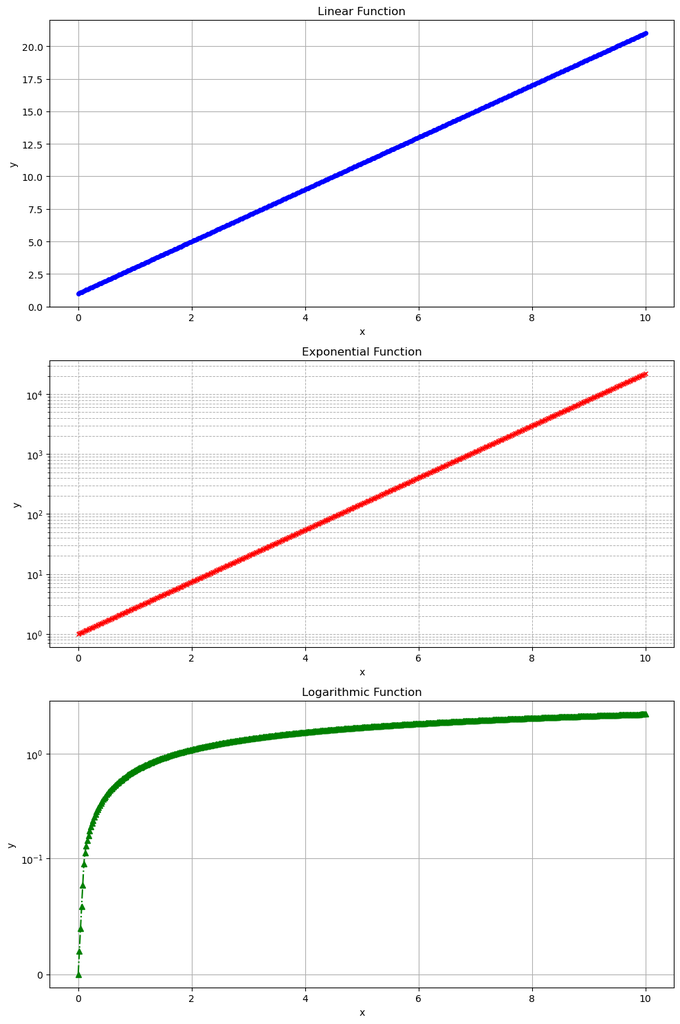

```python
import numpy as np
import matplotlib.pyplot as plt

# Define x range
x = np.linspace(0, 10, 500)

# Linear function
linear_y = 2 * x + 1

# Exponential function
exp_y = np.exp(x)

# Logarithmic function
log_y = np.log(x + 1)  # Adding 1 to avoid log(0)

# Create a figure and axes
fig, axs = plt.subplots(3, 1, figsize=(10, 15))

# Plot linear function on the first subplot
axs[0].plot(x, linear_y, color='blue', linestyle='-', marker='o', markersize=4)
axs[0].set_title('Linear Function')
axs[0].set_xlabel('x')
axs[0].set_ylabel('y')
axs[0].grid(True)

# Plot exponential function on the second subplot with log scale
axs[1].plot(x, exp_y, color='red', linestyle='--', marker='x', markersize=5)
axs[1].set_title('Exponential Function')
axs[1].set_xlabel('x')
axs[1].set_ylabel('y')
axs[1].set_yscale('log')
axs[1].grid(True, which='both', linestyle='--', linewidth=0.7)

# Plot logarithmic function on the third subplot with symlog scale
axs[2].plot(x, log_y, color='green', linestyle='-.', marker='^', markersize=6)
axs[2].set_title('Logarithmic Function')
axs[2].set_xlabel('x')
axs[2].set_ylabel('y')
axs[2].set_yscale('symlog', linthresh=0.1)
axs[2].grid(True)

# Adjust layout
plt.tight_layout()

# Show the plot
plt.show()
```

## ------------------------------------------------------------------------------------------------------------

# TASK 9

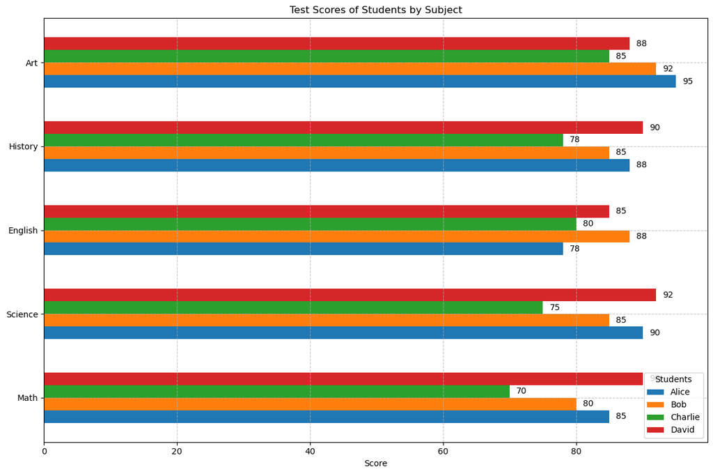

```python
import matplotlib.pyplot as plt
import numpy as np

# Data for the bar chart
subjects = ['Math', 'Science', 'English', 'History', 'Art']
students = ['Alice', 'Bob', 'Charlie', 'David']

# Test scores for each student in each subject
scores = {
    'Alice': [85, 90, 78, 88, 95],
    'Bob': [80, 85, 88, 85, 92],
    'Charlie': [70, 75, 80, 78, 85],
    'David': [90, 92, 85, 90, 88]
}

# Colors for each student
colors = ['#1f77b4', '#ff7f0e', '#2ca02c', '#d62728']

# Number of subjects and students
num_subjects = len(subjects)
num_students = len(students)

# Calculate bar width and positions
bar_width = 0.15
index = np.arange(num_subjects)

# Create the figure and axes
fig, ax = plt.subplots(figsize=(12, 8))

# Create bars for each student
for i, student in enumerate(students):
    # Calculate the position for each student's bars
    bar_positions = index + i * bar_width
    ax.barh(bar_positions, scores[student], bar_width, color=colors[i], label=student)

    # Label the bars with scores
    for pos, score in zip(bar_positions, scores[student]):
        ax.text(score + 1, pos, f'{score}', va='center')

# Set the labels and title
ax.set_yticks(index + bar_width * (num_students - 1) / 2)
ax.set_yticklabels(subjects)
ax.set_xlabel('Score')
ax.set_title('Test Scores of Students by Subject')
ax.legend(title='Students')
ax.grid(True, linestyle='--', alpha=0.7)

# Show the plot
plt.tight_layout()
plt.show()
```

## ------------------------------------------------------------------------------------------------------------